# Dimensionality Reduction Course

Zhaojie Zhang

28 April, 2022

In data science, we are often faced with high dimensional data. In order to use high dimensional data in statistical or machine learning models, dimensionality reduction techniques need to be applied. We can reduce the dimensions of the data using methods like PCA or t-SNE to derive new features, or we can apply feature selection and extraction to filter the data. Along the way, differnt ways of visualizationare also going to be applied to demonstrate the applicabilities of the differnt methods and to explore and interpret the data.

The outline of the Dimensionality Reduction course: (1) PCA and t-SNE (2) feature selection and feature extraction

# 1 setup the environment

```r
library(dplyr)
library(caret)
library(Rtsne)
```

```r
library(ggplot2)
library(psych)
library(ggfortify)
library(textshape)
```

# 2 load and explore the data

## 2.1 load the data

```r
data(cars)
str(cars)
```

```
## 'data.frame':    804 obs. of  18 variables:
##  $ Price      : num  22661 21725 29143 30732 33359 ...
##  $ Mileage    : int  20105 13457 31655 22479 17590 23635 17381 27558 25049 17319 ...
##  $ Cylinder   : int  6 6 4 4 4 4 4 4 4 4 ...
##  $ Doors      : int  4 2 2 2 2 2 2 2 2 4 ...
##  $ Cruise     : int  1 1 1 1 1 1 1 1 1 1 ...
##  $ Sound      : int  0 1 1 0 1 0 1 0 0 0 ...
##  $ Leather    : int  0 0 1 0 1 0 1 1 0 1 ...
##  $ Buick      : int  1 0 0 0 0 0 0 0 0 0 ...
##  $ Cadillac   : int  0 0 0 0 0 0 0 0 0 0 ...
##  $ Chevy      : int  0 1 0 0 0 0 0 0 0 0 ...
##  $ Pontiac    : int  0 0 0 0 0 0 0 0 0 0 ...
##  $ Saab       : int  0 0 1 1 1 1 1 1 1 1 ...
##  $ Saturn     : int  0 0 0 0 0 0 0 0 0 0 ...
##  $ convertible: int  0 0 1 1 1 1 1 1 1 0 ...
##  $ coupe      : int  0 1 0 0 0 0 0 0 0 0 ...
##  $ hatchback  : int  0 0 0 0 0 0 0 0 0 0 ...
##  $ sedan      : int  1 0 0 0 0 0 0 0 0 1 ...
##  $ wagon      : int  0 0 0 0 0 0 0 0 0 0 ...
```

## 2.2 check the correlation of features

For example, you can already see the relatively string positive correlations between price and Cylinder,Cadilac and Convertible, and also the relatively strong negative correlation between price and Chevy.

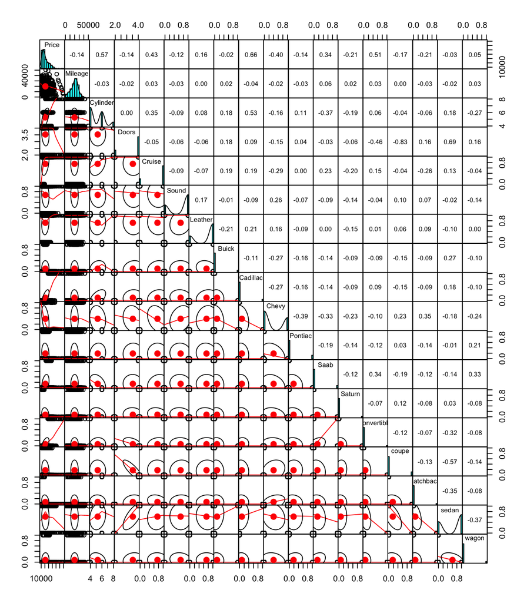

```r
pairs.panels(cars,
             gap = 0,
             pch=21)
```

# 3 Dimensionality reduction methods

## 3.1 PCA

### 3.1.1 Run PCA and print out the summary

You can see that that the 1st components captures 17.2% of the variance in the data, 2nd component captures 14.7% of the variance in the data … For this dataset, the first two components together only help to explain only 31.9% of the variance in the data.

```r
prin_components <- prcomp(cars,
             center = TRUE,
            scale. = TRUE)
summary(prin_components)
```

```
## Importance of components:
##                          PC1    PC2    PC3     PC4     PC5     PC6     PC7
## Standard deviation     1.759 1.6251 1.4413 1.30592 1.19167 1.11351 1.03959
## Proportion of Variance 0.172 0.1467 0.1154 0.09475 0.07889 0.06888 0.06004
## Cumulative Proportion  0.172 0.3187 0.4341 0.52884 0.60773 0.67661 0.73666
##                            PC8     PC9   PC10    PC11    PC12    PC13    PC14
## Standard deviation     1.00433 0.93493 0.8889 0.80731 0.79841 0.66289 0.53726
## Proportion of Variance 0.05604 0.04856 0.0439 0.03621 0.03541 0.02441 0.01604
## Cumulative Proportion  0.79269 0.84125 0.8851 0.92136 0.95678 0.98119 0.99722
##                           PC15      PC16      PC17      PC18
## Standard deviation     0.22355 1.549e-15 6.081e-16 4.424e-16
## Proportion of Variance 0.00278 0.000e+00 0.000e+00 0.000e+00
## Cumulative Proportion  1.00000 1.000e+00 1.000e+00 1.000e+00
```

### 3.1.2 autoplot of the PCA results

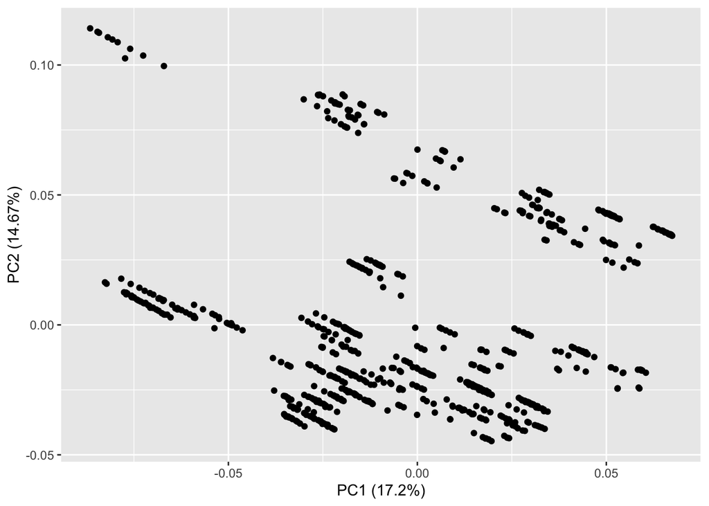

```r
autoplot(prin_components)
```

### You an see the trend of the cars in Price

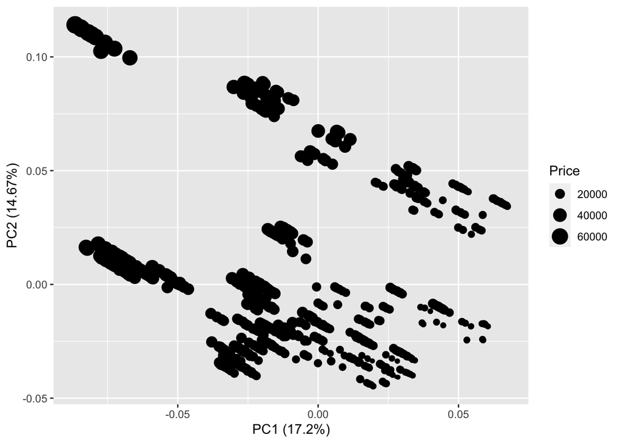

```r
autoplot(prin_components,data=cars,size="Price")
```

### You an see the trend of the cars in Price and the positive correlation with Cylinder

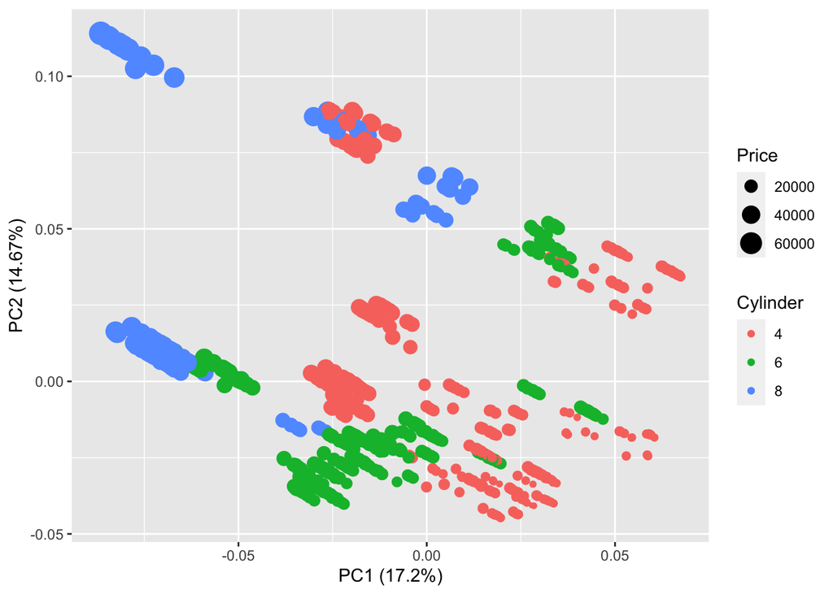

```r
cars$Cylinder <- as.factor(as.character(cars$Cylinder))
autoplot(prin_components,data=cars,size="Price",colour="Cylinder")
```

### You an see the trend of the cars in Price and the positive correlation with Cylinder. On top of that, the eigne vectors for all the features are also added as purple arrows, and you can clearly see their directions (and you can clearly see their relationship with Price from their directions)

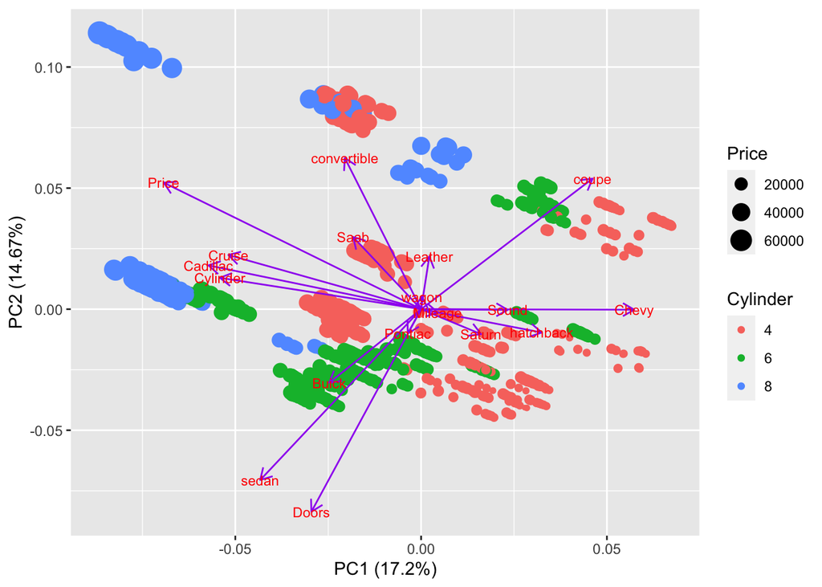

```r
autoplot(prin_components,data=cars,size="Price",colour="Cylinder",loadings.colour = 'purple',loadings=TRUE,loadings.label = TRUE, loadings.label.size = 3)
```

## 3.2 t-SNE

### 3.2.1 run t-SNE and extract the t-SNE components

```r
set.seed(1342)
cars_for_tsne <- cars %>%
  mutate(CarID=row_number())
tsne_trans <- cars_for_tsne %>%
  select(where(is.numeric)) %>%
  column_to_rownames("CarID") %>%
  scale() %>%
  Rtsne()

tsne_df <- tsne_trans$Y %>%
  as.data.frame() %>%
  rename(tsne1="V1",
         tsne2="V2") %>%
  mutate(CarID=row_number()) %>%
  inner_join(cars_for_tsne, by="CarID")
```

## 3.3 plot the t-SNE results: a non-linear representation of the data; you can clearly see from this plot, the cluster of cars where there is a pretty good correlation between price and cylinder , as well as clusters that do not have such correlation.

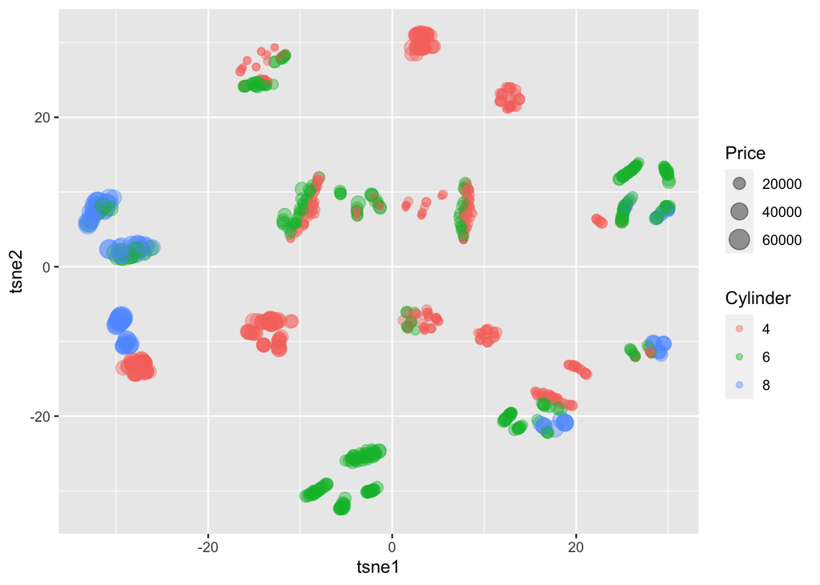

```r
ggplot(tsne_df,aes(x = tsne1,
             y = tsne2,
             size=Price,
             color = Cylinder))+
  geom_point(alpha=0.4)+
  theme(legend.position="right")
```

# 4 Feature selection and extraction for machine learning modeling

There are roughly two groups of feature selection methods: wrapper methods and filter methods.

Wrapper methods evaluate subsets of variables which allows to detect the possible interactions amongst variables.The two main disadvantages of these methods are: (1) The increasing overfitting risk when the number of observations is insufficient. (2) The significant computation time when the number of variables is large

Filter type methods select variables regardless of the model. They are based only on general features like the correlation with the variable to predict. Filter methods suppress the least interesting variables. The other variables will be part of a classification or a regression model used to classify or to predict data. These methods are particularly effective in computation time and robust to overfitting.

Below are a couple of examples:

change the Cylinder type back tp numeric for modeling purposes

```r
cars$Cylinder <- as.numeric(as.character(cars$Cylinder))
```

## 4.1 wrapper method: recursive feature elimination

Preliminary conclusions: the top 5 variables (out of 17): Cadillac, Saab, convertible, hatchback, sedan

```r
set.seed(1342)
feature_size_list <-  c(1:12) # for a total of 18 predictors, pick 1 to 10 predictors

rfe_ctrl <- rfeControl(functions = lmFuncs,
                   method = "repeatedcv",
                   repeats = 5,
                   verbose = FALSE)

rfe_results <- rfe(cars[,-which(colnames(cars) %in% c("Price"))], cars$Price,
                 sizes = feature_size_list,
                 rfeControl = rfe_ctrl)
```

[output not shown]

[output cut: 94 more lines]

[output not shown]

```r
rfe_results
```

```
##
## Recursive feature selection
##
## Outer resampling method: Cross-Validated (10 fold, repeated 5 times)
##
## Resampling performance over subset size:
##
##  Variables RMSE Rsquared  MAE RMSESD RsquaredSD MAESD Selected
##          1 7422   0.4261 5788  589.1    0.09771 308.0
##          2 6073   0.6215 4250  826.5    0.06909 385.3
##          3 5227   0.7146 4007  470.6    0.06875 261.6
##          4 5167   0.7212 4027  456.9    0.06720 248.5
##          5 5161   0.7218 4066  441.1    0.06605 247.9
##          6 3378   0.8847 2476  396.9    0.02150 226.1
##          7 3343   0.8869 2410  396.1    0.02203 229.5
##          8 3317   0.8884 2391  405.3    0.02203 233.5
##          9 3313   0.8888 2375  405.4    0.02182 242.3
##         10 3293   0.8902 2352  413.3    0.02142 252.2
##         11 3295   0.8901 2351  413.4    0.02139 252.3
##         12 3296   0.8900 2358  407.8    0.02146 250.9
##         17 2927   0.9136 2135  327.6    0.01580 197.0        *
##
## The top 5 variables (out of 17):
##    Cadillac, Saab, convertible, hatchback, sedan
```

## 4.2 filter method: single variate filtering method where the features are pre-screened using simple univariate statistical methods, and then only those that pass the criteria are selected for subsequent modeling.

Preliminary conclusions from the results: On average, 14 variables were selected (min = 14, max = 14)

During resampling, the top 5 selected variables (out of a possible 14): Cadillac (100%), Chevy (100%), convertible (100%), coupe (100%), Cruise (100%)

```r
set.seed(1342)
filter_Ctrl <- sbfControl(functions = rfSBF, method = "repeatedcv", repeats = 5)
filter_results <- sbf(cars[,-which(colnames(cars) %in% c("Price"))], cars$Price, sbfControl = filter_Ctrl)
filter_results
```

```
##
## Selection By Filter
##
## Outer resampling method: Cross-Validated (10 fold, repeated 5 times)
##
## Resampling performance:
##
##  RMSE Rsquared  MAE RMSESD RsquaredSD MAESD
##  2378   0.9447 1724  292.2    0.01283   171
##
## Using the training set, 14 variables were selected:
##    Mileage, Cylinder, Doors, Cruise, Sound...
##
## During resampling, the top 5 selected variables (out of a possible 14):
##    Cadillac (100%), Chevy (100%), convertible (100%), coupe (100%), Cruise (100%)
##
## On average, 14 variables were selected (min = 14, max = 14)
```